# SDMs: Honours Guide

Clarke van Steenderen

2025

## First steps

This introductory module to Species Distribution Modelling (SDM) will guide you through all the steps needed to create your first prediction models using the popular MaxEnt tool through R. We will use the Asian Citrus Psyllid (*Diaphorina citri*) as a case study, and generate a predictive MaxEnt model based on global climate variables. *Diaphorina citri* is a major citrus pest and has caused significant financial losses to citrus industries in many regions; in some cases it has threatened their existence. The psyllid is native to Asia, but has spread across the world. It has been recorded in Africa, but it has not dispersed as far south as South Africa yet.

Let’s create a model to predict which regions of South Africa might be the most climatically suitable for *D. citri*, and how it might enter the country through climatically-suitable routes.

🟣 Create a new R project in a folder on your PC, and run the code below bit by bit. You can save this all in one big script, or you can create multiple R scripts for each part of the process. You can use the command `source("script_name.R")` to read in a particular script into your R environment.

🟣 All data required is available here: **https://drive.google.com/drive/folders/1qe3cojnh71l2tmwR4WsdlGPr4fR7CHf0?usp=drive_link** Save this data into the same directory as your R project.

🟢 There are parts of the code that are for you to complete - these are marked by a green dot: 🟢

### Install/load the required R packages, and set the aesthetic theme for the plots

These are the R libraries required to run the various functions we will need. If these are not installed, use `install.packages("library_name")` to save and access the library.

```r
source("setup.R")
```

### Get global climate variables (19 in total) from the [WorldClim Bioclimatic Database](https://www.worldclim.org/data/bioclim.html)

This downloads the 19 climatic variables available on the WorldClim database to your PC, and loads them into R as a SpatRaster object. The `geodata::worldclim_global()` code is commented out because the data has already been downloaded for you, and is in the `data/` folder. If you were downloading this for the first time, you would need to download from the WorldClim database. This data was downloaded at a 2.5 minute degree resolution.

```r
# create a data folder in your current working directory

# dir.create("data/environmental_layers/current", recursive = TRUE, showWarnings = FALSE)

# IF THIS IS THE FIRST TIME, DOWNLOAD THE DATA FROM GBIF:
# wc_current = geodata::worldclim_global(
#     var = "bio",
#     res = 2.5,      # Minute degree resolution of raster layers
#     path = here::here("./data/environmental_layers/current/"),
#     version = "2.1"
# )

# IF NOT THE FIRST TIME, load the WORLDCLIM rasters layers already downloaded
pred_clim = terra::rast( list.files(
  here::here("data/environmental_layers/current/wc2.1_2.5m/") ,
  full.names = TRUE,
  pattern = '.tif'
))

pred_clim

# set the CRS (coordinate reference system) projection for the current climate layers
terra::crs(pred_clim) = "epsg:4326"
terra::crs(pred_clim, describe = T)

# plot the first variable, annual mean temperature:
terra::plot(pred_clim$wc2.1_2.5m_bio_1)
```

Why do you think setting a consistent CRS projection is important?

We now have all 19 climate variables stored as **pred_clim**. Perhaps we want an additional variable, like elevation. Let’s add that to our climate variables as well.

### Get elevation data

Here, we download elevation data in the same way as the climate data above:

```r
# dir.create("data/environmental_layers/elevation/", recursive = TRUE, showWarnings = FALSE)

# pred_altitude = geodata::elevation_global(res = 2.5, path = here::here("data/environmental_layers/elevation/"))

# if already downloaded, read in
pred_elevation = terra::rast(x = here::here(
  "data/environmental_layers/elevation/wc2.1_2.5m/wc2.1_2.5m_elev.tif")
)

# Set the CRS
terra::crs(pred_elevation) = "epsg:4326"
terra::crs(pred_elevation, describe = T)

# plot
terra::plot(pred_elevation)

# check that the CRS for climate and elevation are the same
terra::res(pred_clim)
terra::res(pred_elevation)
```

### Combine climate and elevation data into one raster object

🟢 Create a list called `raster_list`, into which you add the `pred_clim` and `pred_elevation` objects

```r
raster_list = # CREATE LIST

# this turns the objects in raster_list into a raster object
predictors = terra::rast(raster_list)

# Check the variable contains all 20 variables
terra::nlyr(predictors)

predictors
```

### Download GPS records from GBIF

🟢 Download all GBIF records for **Diaphorina citri** and:

- Keep only the `species`, `lat`, and `lon` columns
- Save the data frame as an RDS file
- There is a CSV file in the `data/gps/` folder called `Diaphorina_citri.csv`. Read this file into R, and select only the `species`, `lat`, and `lon` columns. Rename these columns like this: `dplyr::select(species, lat = decimalLatitude, lon = decimalLongitude)`
- Create a single data frame that contains both the GBIF download data, and the CSV data that you have just read in. Call this data frame `sp_gps`
- Select only the `species`, `lon`, and `lat` columns, and save that as a new object called `sp_data`
- Keep only distinct GPS coordinates

```r
# Download all available Diaphorina citri records from GBIF here

# keep just the columns with species name, latitude, and longitude values

# save as RDS

# Read in the CSV file from here: data/gps/Diaphorina_citri.csv

# combine everything
sp_gps = # BIND YOUR DATASETS HERE

# Keep only the species, lon, and lat columns
sp_data = sp_gps %>%
  # SELECT COLUMNS HERE

# remove duplicate GPS records
sp_data = sp_data %>%
  # KEEP DISTINCT LAT AND LON RECORDS
```

Now we need to filter the data further so that we keep only one GPS record per grid cell:

```r
# Convert one of our environmental pred_clim into a raster layer
r = raster::raster(pred_clim[[1]])

# Extract longitude and latitude into a dataframe
xy = sp_data %>%
  dplyr::select(lon, lat) %>%
  as.data.frame(.)
head(xy)

# Retain only 1 GPS record per grid cell
set.seed(2012)
sp_data_thin = dismo::gridSample(
  xy = xy,     # Data.frame containing lon/lat columns only
  r = r ,      # Environmental raster (must be a raster, not spatRast object)
  n = 1        # Number of records to keep per cell
)

# let's see how many GPS points we have left in our thinned dataset
nrow(sp_data)
nrow(sp_data_thin)
```

🟢 Compare the number of rows between `sp_data` and `sp_data_thin` -> How many records were dropped when we extracted one GPS record per grid cell?

Going forward, we’ll use `sp_data_thin` as our data set of GPS points.

🟢 Fill in the missing bits below to get a map of the world, with our GPS points overlaid onto it. The conditional `ifelse` statements in the `geom_point(aes())` section give different colours and shapes to the points in the native vs invaded range.

Now save the map as an RDS and PNG file.

```r
# Get a world map
world_map = rnaturalearth::ne_countries(
  scale = "medium",
  returnclass = "sf"
)

# Plot GPS points on world map to check our locality data is correct
global_distr = ggplot() +
  # Add raster layer of world map
  geom_sf(data = YOURWORLDMAP, alpha = 0.5) +
  # Add GPS points
  geom_point(
    data = YOURDATA,
    size = 0.5,
    aes(
      x = lon,
      y = lat,
      color = ifelse(lon > 60, "red", "black"),
      shape = ifelse(lon > 60, "triangle", "circle")
    )
  )  +
  scale_colour_manual(values = c("red", "black")) +
  # Set world map CRS
  coord_sf(
    crs = 4326,
    ylim = c(-58, 90),  # Clip below -52 degrees latitude
    expand = FALSE
  ) +
  xlab("Longitude") +
  ylab("Latitude")

global_distr

# save the global map
ggsave(SAVE HERE)
```

🟢 Using your `sp_data_thin` data frame, create another data frame called `species_native`, where you filter the original so that it only keeps records where the longitude is **greater than** 60 degrees East. This object will contain all records from the psyllid’s native range in Asia. Do a quick check to see how many records there are in the native range data frame.

```r
species_native = sp_data_thin %>%
  # FILTER LONGITUDE HERE

# CHECK HOW MANY ROWS species_native HAS HERE
```

🟢 Now do the same for the invaded range, where you call the data frame `species_invaded`. Filter the data so that you keep all records where longitude is **less than** 60 degrees East. Check how many records there are in this invaded range data frame.

```r
# Filter GPS records from the invaded range only

# get just the invaded range (remove all native range GPS coordinates)
species_invaded = sp_data_thin %>%
  # FILTER LONGITUDE HERE

# CHECK HOW MANY ROWS species_invaded HAS HERE
```

The code block below just crops all our climate variable data to the size of the native and invaded ranges, so that we only have to work with the data we need (otherwise we retain all the climate data for the whole world, which is unnecessarily clumsy).

```r
species_native_extent = sf::st_as_sf(species_native, coords = c("lon", "lat"), crs = 4326)
species_native_extent = sf::st_bbox(species_native_extent)

# crop the predictors
pred_clim_native_range = raster::crop(predictors, species_native_extent)
plot(pred_clim_native_range$wc2.1_2.5m_bio_1)

species_invaded_extent = sf::st_as_sf(species_invaded, coords = c("lon", "lat"), crs = 4326)
species_invaded_extent = sf::st_bbox(species_invaded_extent)

pred_clim_invaded_range = raster::crop(predictors, species_invaded_extent)
plot(pred_clim_invaded_range$wc2.1_2.5m_bio_1)
```

Here, we can have a look at how many GPS records fall within certain areas, if we provide the bounding boxes (lat and lon) for those regions:

```r
# How many points in the USA?

species_usa = sp_data_thin %>%
  dplyr::filter(lon > -127, lon< -65, lat > -5, lat < 50)

print(paste("There are", nrow(species_usa), "GPS points in the USA.") )

# How many points in Brazil?

species_braz = sp_data_thin %>%
  dplyr::filter(lon > -73.99, lon < -34.80, lat > -33.75, lat < 5.27)

print(paste("There are", nrow(species_braz), "GPS points in Brazil.") )

# How many points in Africa?

species_afr = sp_data_thin %>%
  dplyr::filter(lon > -26, lon < 55, lat > -48, lat < 40)

print(paste("There are", nrow(species_afr), "GPS points in Africa.") )
```

### Multicollinearity: which variables do we choose?

We currently have 20 variables: 19 climate and 1 elevation. There will be some variables that are correlated with each other (e.g. low precipitation might be strongly correlated with high temperature). In these cases, including all correlated variables can be redundant, and it can become difficult to tease apart the more important ones that are actually affecting the model the most. Here, we run a correlation test, and select the variables we decide are the most important for this particular case.

```r
# Extract the climate and elevation data at each presence GPS record for ACP
clim_sp = terra::extract(
  x = predictors,  # SpatRast containing all 19 WORLDCLIM layers + elevation
  y = sp_data_thin # data.frame containing GPS of study taxon (lon, lat)
) %>%
  dplyr::select(-ID) %>% # drop the ID column
  na.omit() # remove any NA values

# create a copy of clim_sp, so that we can run a correlation test on it without altering the original
clim_sp_corr = clim_sp

# change the variable names to a shorter simpler version
new_colnames = gsub(".*_(\\d+)$", "\\1", names(clim_sp_corr))
names(clim_sp_corr) = new_colnames

# order the variables from 1 to 19, rather than 1, 10, 11, etc.
clim_sp_corr = clim_sp_corr[, gtools::mixedsort(names(clim_sp_corr))]

# change the name of the elevation column to make it simpler
clim_sp_corr = clim_sp_corr %>% rename(elevation = wc2.1_2.5m_elev)
```

🟢 Run a Spearman’s correlation test on `clim_sp_corr` using the `cor()` function.

```r
cor_mat = # RUN CORRELATION TEST HERE
```

Let’s have a look at the results:

```r
# have a look at a correlation matrix plot
cor_mat[cor_mat == 1 ] = 0
corrplot::corrplot(cor_mat, type = "upper", order = "original",
         tl.col = "black", tl.srt = 0)

# identify strongly correlated variables
# 0.7 is a standard threshold in the literature, but you can alter this value

CORR.VAL = 0.7
cor_mat[cor_mat < CORR.VAL & cor_mat > -CORR.VAL] = 0

# create a correlation newtork
network = igraph::graph_from_adjacency_matrix(cor_mat, weighted=T, mode="undirected", diag=F)
plot(network, vertex.color = "lightgreen")
```

The connection lines in the network plot show the variables that are strongly correlated, and so we need to select the best ones to continue with. This can be subjective!

**bio 1, bio 2, bio 5, bio 7, bio 9, bio 12, bio 15, bio 19, and elevation.**

As a reminder, these are the bio codes:

**BIO1** = Annual Mean Temperature  
**BIO2** = Mean Diurnal Range (Mean of monthly (max temp - min temp))  
**BIO3** = Isothermality (BIO2/BIO7) (×100)  
**BIO4** = Temperature Seasonality (standard deviation ×100)  
**BIO5** = Max Temperature of Warmest Month  
**BIO6** = Min Temperature of Coldest Month  
**BIO7** = Temperature Annual Range (BIO5-BIO6)  
**BIO8** = Mean Temperature of Wettest Quarter  
**BIO9** = Mean Temperature of Driest Quarter  
**BIO10** = Mean Temperature of Warmest Quarter  
**BIO11** = Mean Temperature of Coldest Quarter  
**BIO12** = Annual Precipitation  
**BIO13** = Precipitation of Wettest Month  
**BIO14** = Precipitation of Driest Month  
**BIO15** = Precipitation Seasonality (Coefficient of Variation)  
**BIO16** = Precipitation of Wettest Quarter  
**BIO17** = Precipitation of Driest Quarter  
**BIO18** = Precipitation of Warmest Quarter  
**BIO19** = Precipitation of Coldest Quarter

```r
# specify the variables we want to keep
vars_reduced_r2 = c(
  "wc2.1_2.5m_bio_1",
  "wc2.1_2.5m_bio_2",
  "wc2.1_2.5m_bio_5",
  "wc2.1_2.5m_bio_7",
  "wc2.1_2.5m_bio_9",
  "wc2.1_2.5m_bio_12",
  "wc2.1_2.5m_bio_15",
  "wc2.1_2.5m_bio_19",
  "wc2.1_2.5m_elev"
)

# reduce our original full set of predictor variables to the ones specified above
reduced_preds = terra::subset(x = predictors, subset = vars_reduced_r2)

# extract the data for each GPS record
clim_sp_reduced = terra::extract(
  x = reduced_preds,
  y = sp_data_thin
) %>%
  dplyr::select(-ID) %>% # drop the ID column
  na.omit() # remove any NA values

# a common approach is to run a follow-up test, using a Variance Inflation Factor method (VIF)
# this is another method of assessing multicollinearity between variables, where a threshold value of 5
# indicates moderate collinearity
usdm::vifstep(clim_sp_reduced, th = 5)
```

```r
vars_reduced_r2_VIF = c(
  "wc2.1_2.5m_bio_1",
  "wc2.1_2.5m_bio_2",
  "wc2.1_2.5m_bio_5",
  "wc2.1_2.5m_bio_9",
  "wc2.1_2.5m_bio_12",
  "wc2.1_2.5m_bio_15",
  "wc2.1_2.5m_bio_19",
  "wc2.1_2.5m_elev"
)

# reduce our original full set of predictor variables to the ones specified above
reduced_preds = terra::subset(x = predictors, subset = vars_reduced_r2_VIF)

# write this raster as a tif file
terra::writeRaster(reduced_preds, "reduced_preds.tif")
```

### Presence Points

Now that we have the predictor variables we want, we need to set up a data frame that contains the climate variable data at each recorded presence GPS point.

```r
# if not still in the R environment, read in our reduced predictor SpatRaster (tif file), and GPS presence points
reduced_preds = terra::rast("data/reduced_preds.tif")
sp_data_thin = readRDS("data/sp_data_thin.rds")

# extract all the data at the GPS points for ACP
speciesEnv = base::data.frame( raster::extract(reduced_preds,
                cbind(sp_data_thin$lon, sp_data_thin$lat)) )

# add the lat and lon columns to the data
speciesWd = cbind(sp_data_thin, speciesEnv)

# clean the data frame, and add a column with the species name for ACP
speciesWd = as.data.frame(speciesWd) %>%
    dplyr::select(
      decimalLatitude = lat,
      decimalLongitude = lon,
      dplyr::all_of(names(reduced_preds))
    ) %>%
    dplyr::mutate(species = "Diaphorina citri") %>%
    dplyr::select(species, everything()
    ) %>%
  na.omit()

# Reproject the CRS
coordinates(speciesWd) =  ~ decimalLongitude + decimalLatitude
crs_wgs84 = CRS(SRS_string = "EPSG:4326")
slot(speciesWd, "proj4string") = crs_wgs84

speciesWd = as.data.frame(speciesWd)
head(speciesWd)

# Let's call this presPoints for clarity
presPoints = speciesWd

# save to file
saveRDS(object = presPoints, file = "data/presPoints.rds")
```

### Background Points (Pseudo-absences)

We need to generate background GPS points where we think we will be unlikely to record ACP. This is quite a debated topic in SDM work, as these pseudo-absence points are generated based on statistical approaches, rather than actual verified data. Nevertheless, a good approach is to select points from regions that are at least somewhat similar to presence areas in terms of climate type. Here, we’ll use Köppen-Geiger climate data to select similar eco-regions to randomly sample points from.

```r
# read in the koppen-geiger (KG) data
kg_layer = sf::st_read("koppen_geiger")

# Reproject KG layer
geo_proj = "+proj=longlat +datum=WGS84 +no_defs +ellps=WGS84 +towgs84=0,0,0"
kg_layer = sf::st_transform(kg_layer, geo_proj)

# Coerce GPS records into SpatialPointsDataFrame
records_spatial = sp::SpatialPointsDataFrame(
  coords = cbind(sp_data_thin$lon, sp_data_thin$lat),
  data = sp_data_thin,
  proj4string = CRS('+proj=longlat +datum=WGS84 +no_defs +ellps=WGS84 +towgs84=0,0,0')
)

# Select KG ecoregions in which there is at least one GPS record
kg_sp = as(kg_layer, "Spatial")
kg_contain = kg_sp[records_spatial, ]

# Define background area by masking predictor layers to just the KG zones with at
# least 1 GPS record
# Convert the KG zones containing GPS records back into an 'sf' object
crs_wgs84 = CRS(SRS_string = "EPSG:4326")
kg_contain = sf::st_as_sf(kg_contain)
kg_contain = sf::st_set_crs(kg_contain, crs_wgs84)

bg_area = terra::mask(reduced_preds, kg_contain)

terra::writeRaster(bg_area, "data/bg_area.tif")
```

```r
presPoints = readRDS("data/presPoints.rds")
bg_area = terra::rast("data/bg_area.tif")

# Plot to check the mask worked -> this is the area where we will pick background points from
terra::plot(bg_area$wc2.1_2.5m_bio_1)
```

Now that we have an area from which to select background points, we can go ahead and randomly select 10,000 points (without replacement). Then, as before, we will extract our predictor variable data at those points and create a SpatRaster .tif file.

```r
# setting a seed makes this process repeatable, if you re-run this again
set.seed(2023)

bg_points = terra::spatSample(
    x = bg_area,        # Raster of background area to sample points from
    size = 10000,       # How many background points do we want?
    method = "random",  # Random points
    replace = FALSE,    # Sample without replacement
    na.rm = TRUE,       # Remove background points that have NA climate data
    as.df = TRUE,       # Return background points as data.frame object
    xy = TRUE           # Return lat/lon values for each background point
  ) %>%
dplyr::rename(lon = x, lat = y)

head(bg_points)

terra::plot(kg_contain, col="khaki")
points(bg_points$lon,
       bg_points$lat,
       pch = 21,
       bg = 'black',
       cex = 0.2)
points(sp_data_thin$lon,
       sp_data_thin$lat,
       pch = 21,
       bg = 'red',
       cex = 1)
```

If you want to make sure that no background points are selected at the same position as a presence point, you can use the `predicts::backgroundSample()` function shown below.

```r
bg_points2 = predicts::backgroundSample(
  mask = bg_area,
  n = 10000,
  p = sp_data_thin,
  excludep = TRUE
)

head(bg_points2)
```

Alternatively, you could take your `bg_points` from before, compare it to your presence points in `sp_data_thin`, and remove any lon-lat pairs that are identical:

```r
# Assume df1 and df2 have columns "lon" and "lat"
common_points = dplyr::inner_join(bg_points, sp_data_thin, by = c("lon", "lat"))

# View how many matches were found
nrow(common_points)
```

```r
# clean the data frame, and add a column with the species name for ACP
bg_pointsWd = as.data.frame(bg_points) %>%
    dplyr::select(
      decimalLatitude = lat,
      decimalLongitude = lon,
      dplyr::all_of(names(reduced_preds))
    ) %>%
    dplyr::mutate(species = "Diaphorina citri") %>%
    dplyr::select(species, everything() )

# Reproject CRS
coordinates(bg_pointsWd) =  ~ decimalLongitude + decimalLatitude
crs_wgs84 = CRS(SRS_string = "EPSG:4326")
slot(bg_pointsWd, "proj4string") = crs_wgs84

bg_pointsWd = as.data.frame(bg_pointsWd)
head(bg_pointsWd)

# Let's call this backPoints for clarity
backPoints = bg_pointsWd

# save to file
saveRDS(object = backPoints, file = "data/backPoints.rds")
```

As an aside, let’s add some buffering around presence points, and remove any background points that fall within that buffer. Let’s try a 300 km buffer zone around each presence point:

```r
world_map = rnaturalearth::ne_countries(
  scale = "medium",
  returnclass = "sf"
)

# Convert data frames to sf objects
pres_sf = sf::st_as_sf(sp_data_thin, coords = c("lon", "lat"), crs = 4326)
bg_sf = sf::st_as_sf(bg_points, coords = c("lon", "lat"), crs = 4326)

# Transform to projected CRS (for distance-based buffering in meters)
pres_sf_proj = sf::st_transform(pres_sf, crs = 3395)
bg_sf_proj   = sf::st_transform(bg_sf, crs = 3395)

# Create buffer around presence points (in meters)
# let's apply a 300 km buffer zone here. You can experiment with other values
pres_buffer = sf::st_buffer(pres_sf_proj, dist = 300000)

# Transform buffers back to geographic coordinates for plotting
pres_buffer_latlon = sf::st_transform(pres_buffer, crs = 4326)

# Combine buffers into a single geometry
pres_union = st_union(pres_buffer)

# Filter out background points that fall within the buffer
bg_filtered = bg_sf_proj[!st_intersects(bg_sf_proj, pres_union, sparse = FALSE), ]

# Transform back to geographic coordinates
bg_filtered_latlon = st_transform(bg_filtered, crs = 4326)

########################
# before buffering
########################

ggplot() +
  geom_sf(data = pres_buffer_latlon, fill = "royalblue", alpha = 0.3, color = NA) +  # translucent buffer
  geom_sf(data = world_map, alpha=0.5) +
  geom_sf(data = pres_sf, color = "black", size = 2) +  # presence points
  geom_sf(data = bg_sf, color = "darkred", size = 0.5) +
  labs(title = "Presence Points with 300 km Buffers")

########################
# after buffering
########################

buffer.map = ggplot() +
  geom_sf(data = pres_buffer_latlon, fill = "royalblue", alpha = 0.3, color = NA) +  # translucent buffer
  geom_sf(data = world_map, alpha=0.5) +
  geom_sf(data = pres_sf, color = "black", size = 2) +  # presence points
  geom_sf(data = bg_filtered_latlon, color = "darkred", size = 0.5) +
  labs(title = "Presence Points with 300 km Buffers")

saveRDS(buffer.map, "data/buffer.map.rds")

# Convert back to data frame
backPoints.buffer = bg_filtered_latlon %>%
 dplyr::mutate(lon = st_coordinates(.)[,1],
         lat = st_coordinates(.)[,2]) %>%
  sf::st_drop_geometry()

# save to file
saveRDS(object = backPoints.buffer, file = "data/backPoints.buffer.rds")
```

With the buffering, you should get a map like this:

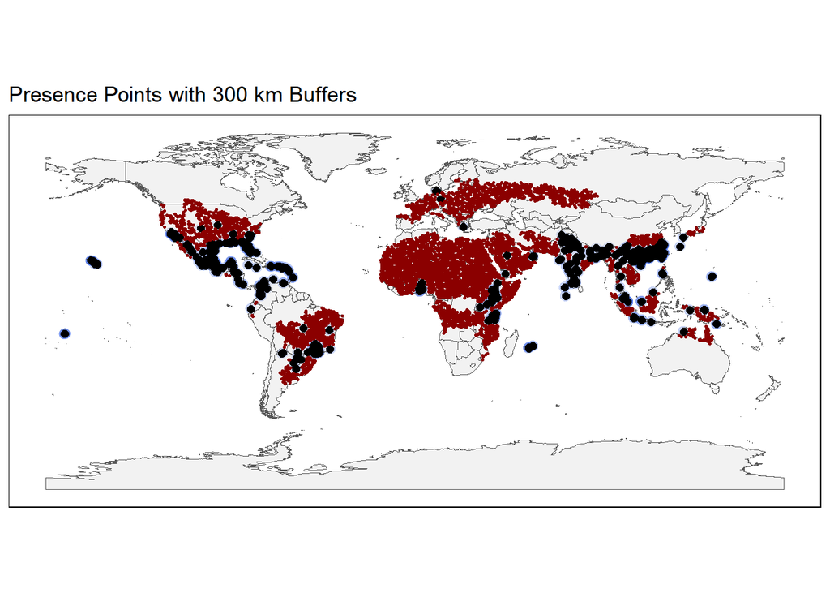